# Lecture 3: Focus

Nick Huntington-Klein

02 April, 2020

## Clutter and Focus

- We want to tell a story with our data
- Some stories are clear
- Others are complex
- They all need to be clear
- And we may need to walk the reader along

## The Three Rules of Presentation

- Tell them what you’re going to tell them
- Tell them
- Tell them what you told them

## Presentation

- Your audience does not know what you know
- In many cases they may not care as much as you care
- And even if they know and care, they may not understand the way you think about it
- Don’t be afraid to hold their hand

## Presentation

- When transmitting information, always let the reader know where to go
- Really well-done research or argumentative writing makes the reader think of the next point you’re going to make before you even make it
- Similarly, well done data communication doesn’t assume knowledge of the reader and is willing to direct their attention.

## Focus

- We are already trying to focus our reader by making the viz in the first place
- After all, we could avoid focusing them entirely by just showing the full data set, but we don’t do that
- Can we focus them further to make the story even clearer?

## Preattentive Attributes

- Our brain knows what to look out for
- How can we direct the eye where we need it to go?
- Thankfully, (most of) you have been looking with your eyes your whole life!
- So this should be pretty intuitive

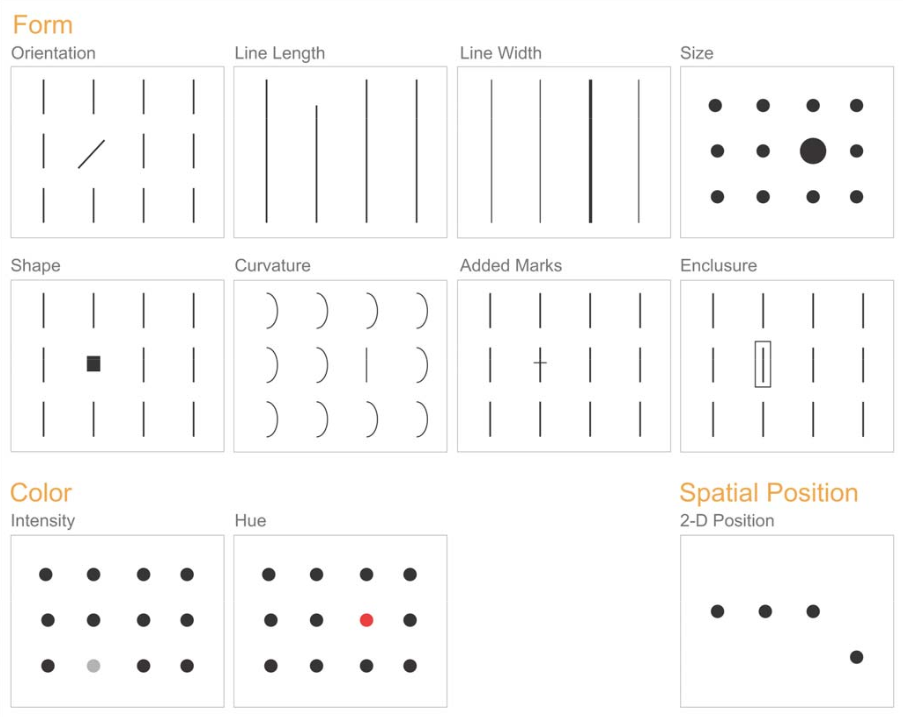

## Preattentive Attributes in Images

- Note some overlap here with our attributes for categorizing things
- But here the purpose is not to distinguish two equal things
- But rather to emphasize one important thing!
- Let’s go through some commonly usable ones:

## Color

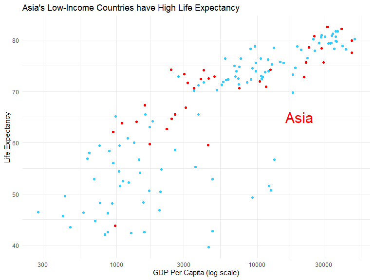

## Intensity

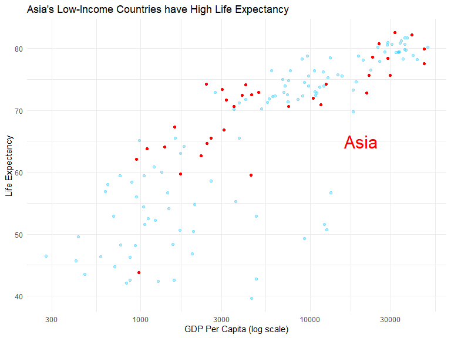

## Size

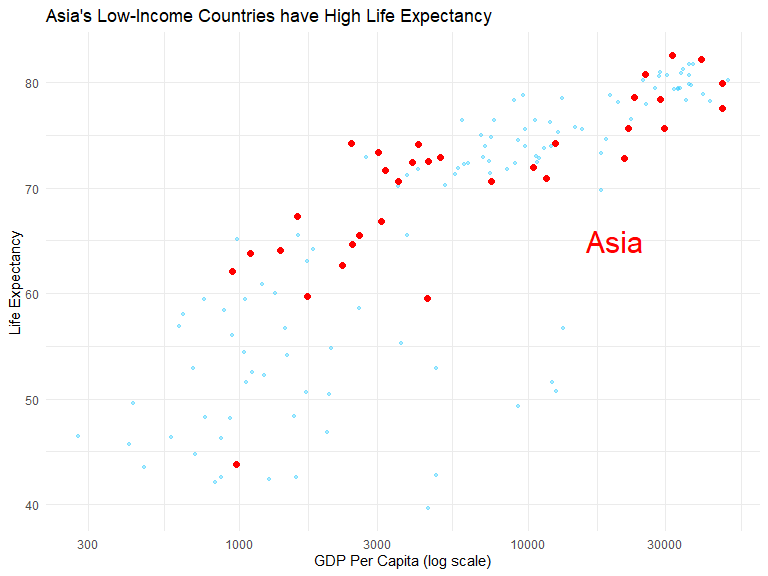

## Width

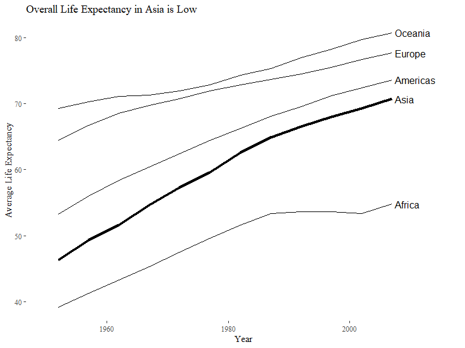

## Enclosure

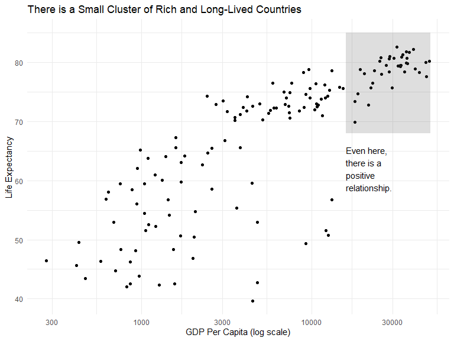

## Preattentive Attributes in Text

- These are more obvious
- Bold, color, italics, size, spatial separation, enclosure, underline

## Keep in Mind

- With all of these attributes, some are more important than others!
- And more intensity generally means more attention
- Rather than providing a direct order, remember that it’s subjective - try things out, see what is intuitive

## An Example

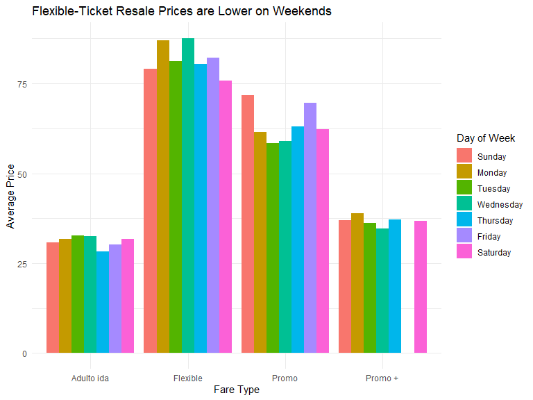

## Use Color Sparingly

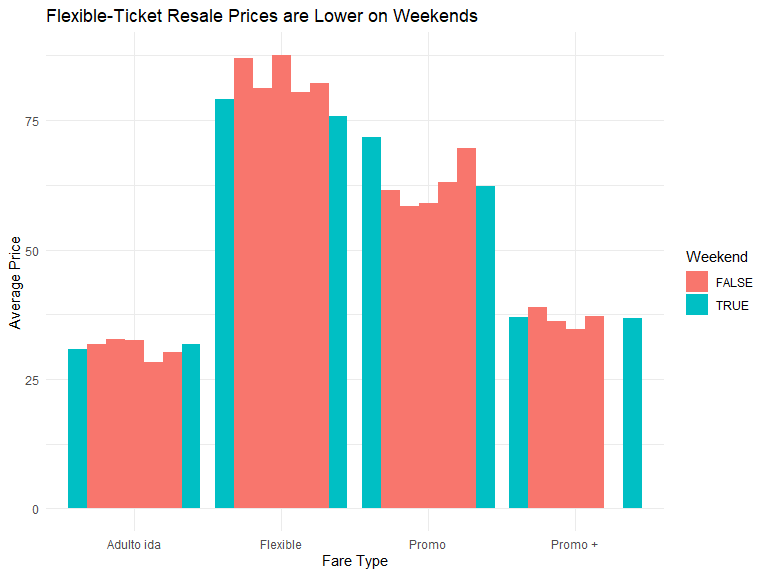

## Choose Colors for Focus

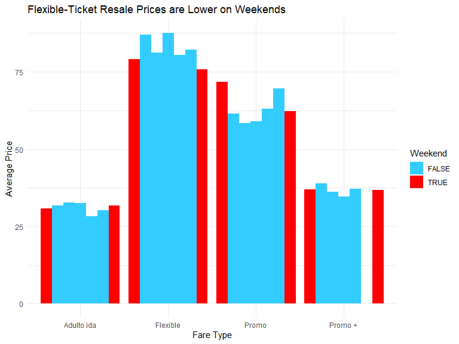

## Also Make Them Look Good

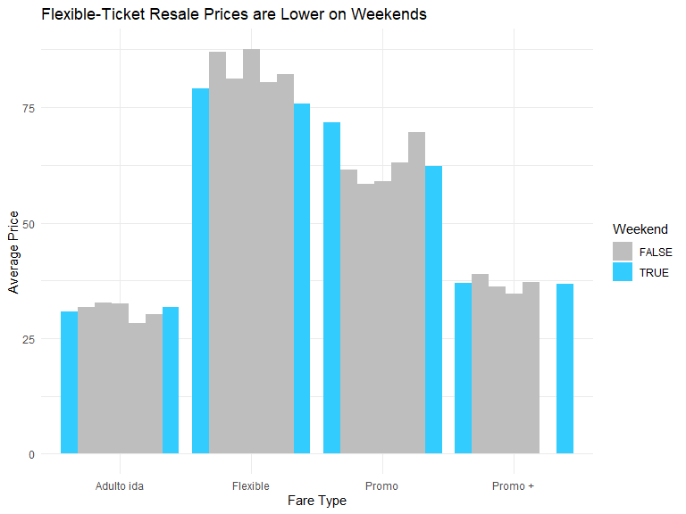

## Choose Intensity for Focus

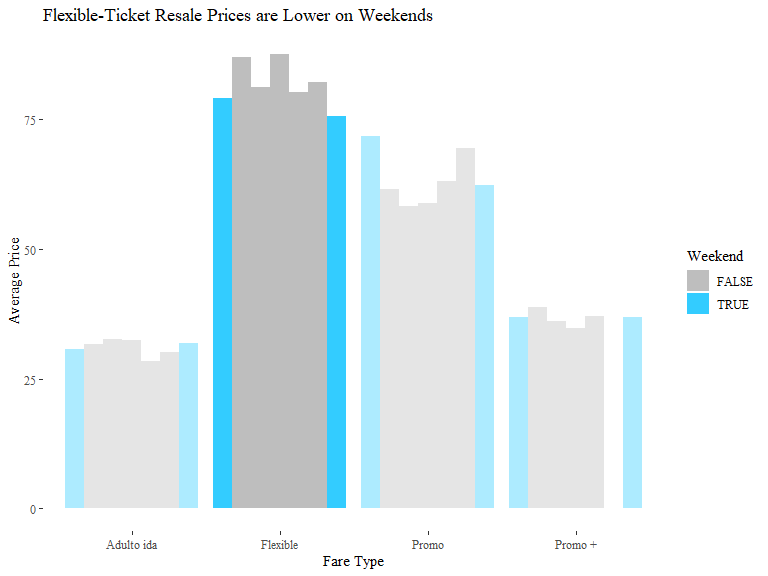

## Proximity for Focus and Comparison

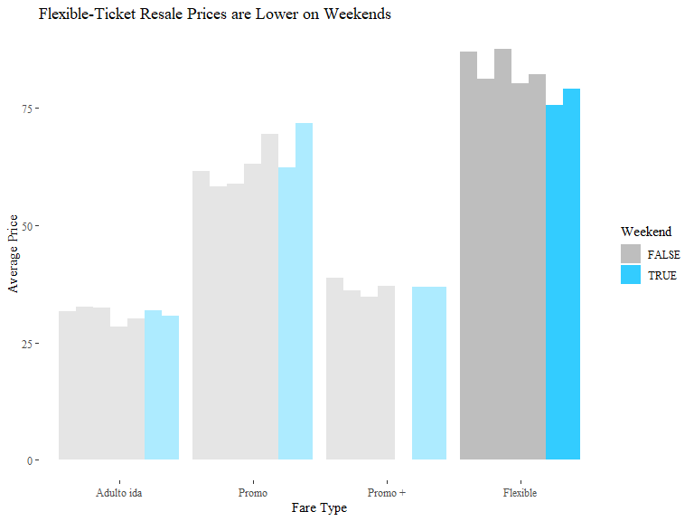

## Declutter

- Labels might not even be necessary!

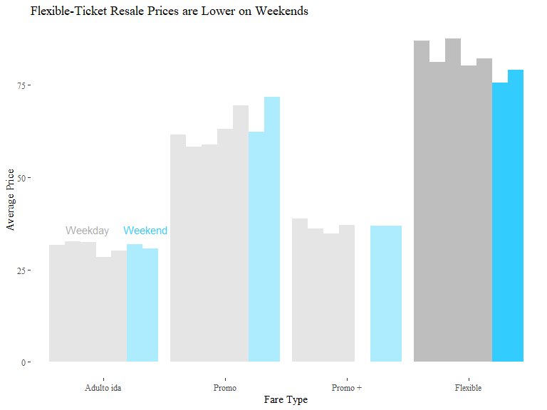

## Annotation

- Annotation can be a great way of pointing out features of the data
- But don’t go wild! Reserve it
- Remember - *walk your audience through the data*, and don’t be afraid to interpret for them!

## Could we Go Further?

- Declutter with days-of-week $\rightarrow$ just one point for weekday, one for weekend
- Do we need the other ticket types?
- Slope graph?
- Move the title in closer?

## Color

- Color is a very important element here
- Often the easiest tool for distinguishing things
- And very important in making the graph look good

## Things to Know about Color

- Matching color schemes and complementary colors (uh, ask someone else)
- Types of color palettes (in most software, available prepackaged!)
- Designing for the colorblind

## Color Palettes

Two main kinds of palettes:

- Sequential, for showing variation along an axis (more and less)
- (Divergent sequential for low-middle-high)
- Distinct/qualitative, for showing different groups

## Sequential Palettes

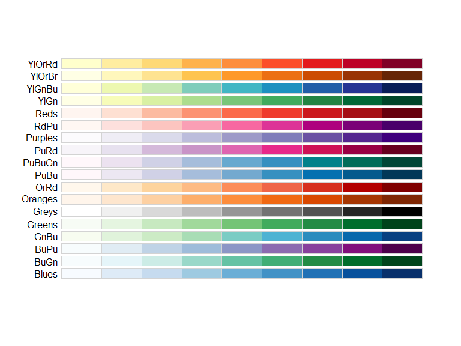

## Divergent Sequential Palettes

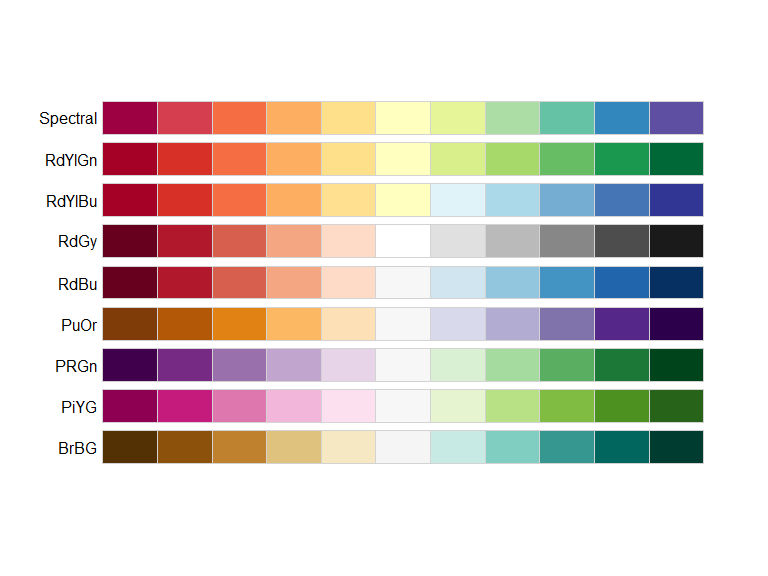

## Distinct/Qualitative Sequential Palettes

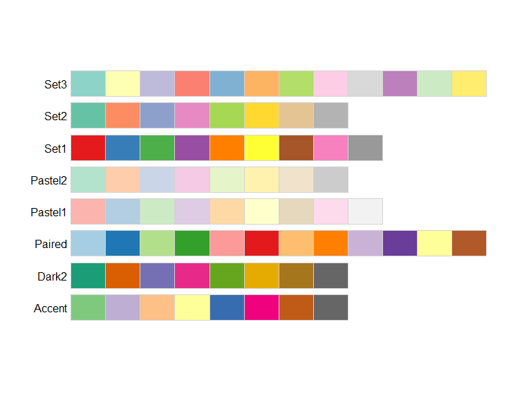

## Color Blindness

- Most common is red/green/(orange)
- Blue/yellow also relatively common
- Some people have zero color vision

## Color Blindness

- When picking colors, avoid having your contrasts be red/green or blue/yellow. Red/blue is a popular choice here.
- For complete accessibility, focus on highly contrasting *shades*
- People who are colorblind can still generally differentiate opacity and intensity
- Colorblind-friendly palettes are available!

## Colorblind-friendly palettes

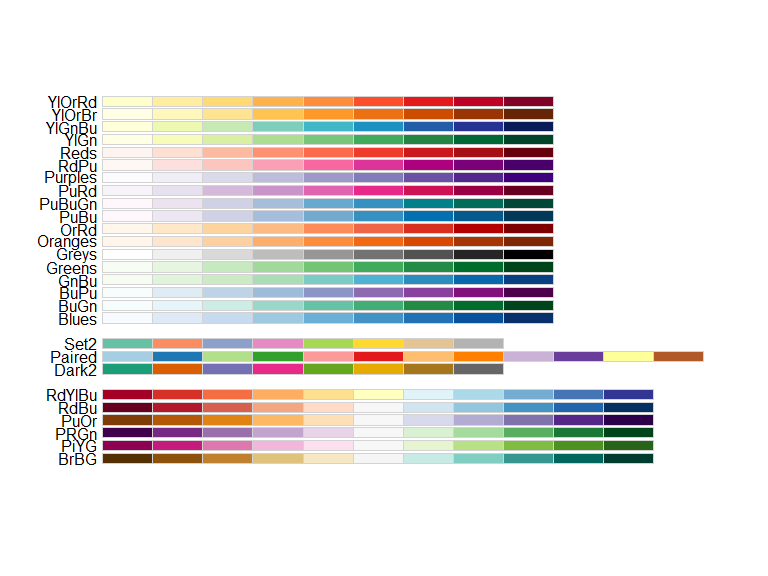

## Designing for Focus

- Highlight what’s important
- Remove distractions
- Unimportant stuff CAN be backgrounded

## Together

- Let’s work with some data and figure out our ideal design together

| Name | Class | Label | Values |
| --- | --- | --- | --- |
| airline | integer | Airline | Num: 1 to 6 |
| year | integer | Year | Num: 1 to 15 |
| cost | integer | Cost in Thousands | Num: 68978 to 4748320 |
| output | numeric | Output in Revenue Passenger Miles | Num: 0.038 to 1.936 |
| pf | integer | Fuel Price | Num: 103795 to 1015610 |
| lf | numeric | Load Factor | Num: 0.432 to 0.676 |

## Exploring

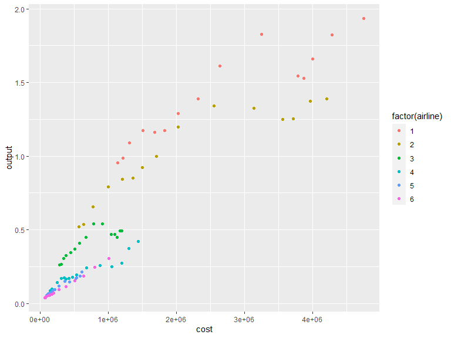

## Exploring

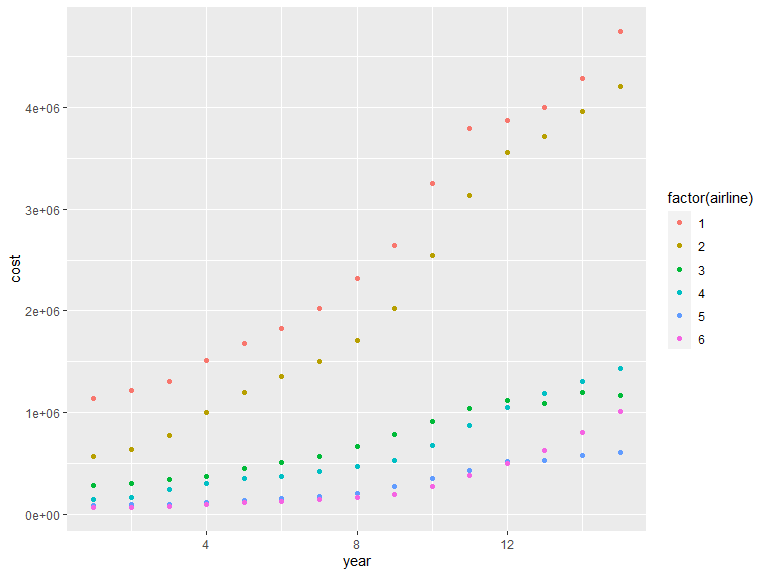

## Exploring

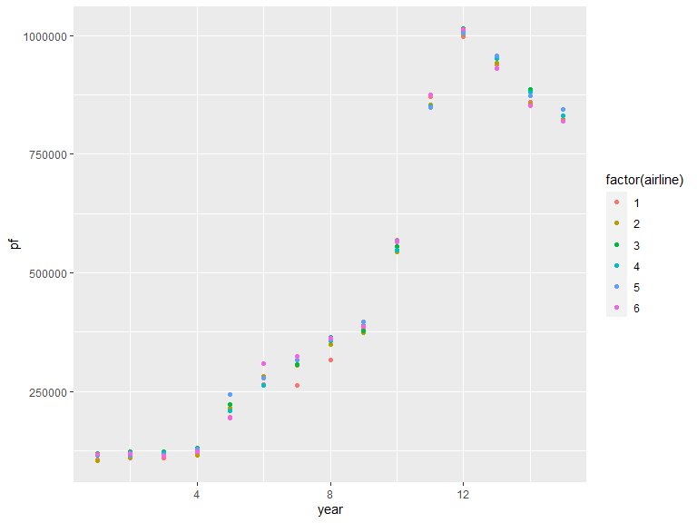